# HW1

## R Markdown

### 1. Add libraries

```r
library(knitr)
library(GEOquery)
library(AnnotationDbi)
library(Biobase)
library(ggplot2)
library(reshape2)
library(limma)
library(MASS)
library(PCAtools)
library(dplyr)
library(org.Hs.eg.db)
library(fgsea)
source("https://raw.githubusercontent.com/assaron/r-utils/master/R/exprs.R")
```

### 2. Obtain the GSE126296 dataset

The GSE126296 dataset contains info on the gene expression levels of 14 participants before and after running a sprint.

```r
es <- getGEO("GSE126296", AnnotGPL = TRUE)
es <- es[[1]]

es <- collapseBy(es, fData(es)$`Gene symbol`, FUN=median)
es <- es[!grepl("///", rownames(es)), ]
es <- es[rownames(es) != "", ]

fData(es) <- data.frame(row.names = fData(es)$`Gene symbol`)
```

### 3. Process GE data.

Check whether data is linear:

```r
max(exprs(es))
```

```
## [1] 32184.5
```

Apply log-transformation, perform quantile normalization, only leave the 10000 most expressed genes.

```r
exprs(es) <- log2(exprs(es)+1)
exprs(es) <- normalizeBetweenArrays(exprs(es), method="quantile")

es <- es[head(order(apply(exprs(es), 1, mean), decreasing = TRUE), 10000), ]
```

Let's see the boxplots of the expression levels in samples:

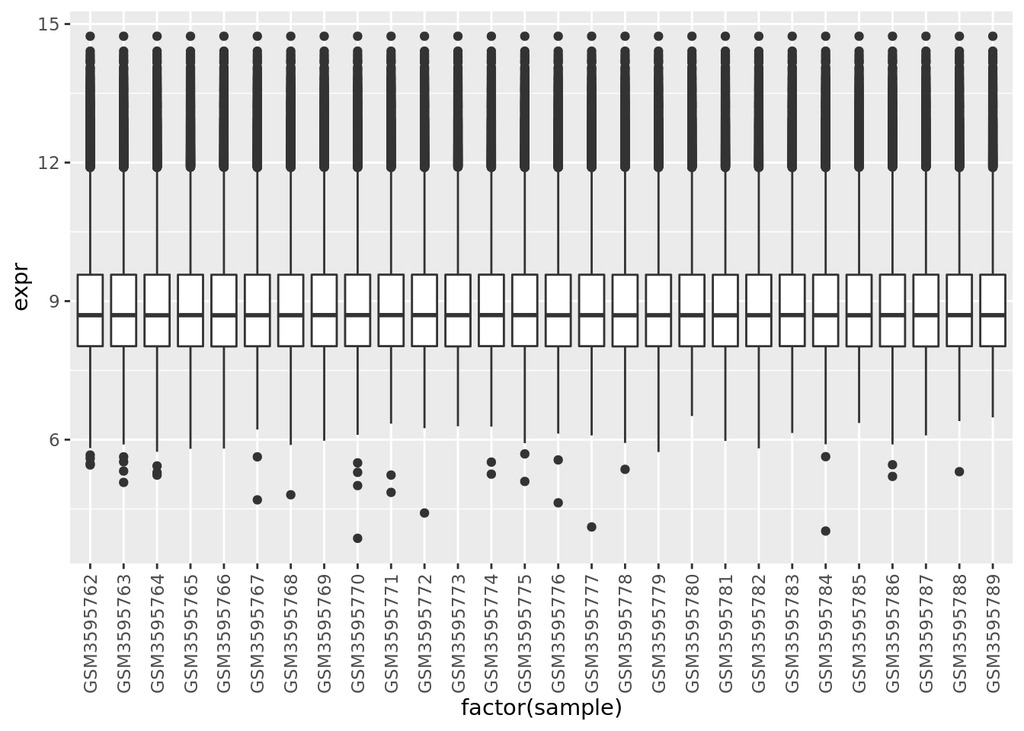

```r
meltData <- melt(exprs(es))[, c(2,3)]
colnames(meltData) <- c('sample', 'expr')

ggplot(meltData, aes(factor(sample), expr)) +
  geom_boxplot() +
  theme(axis.text.x = element_text(angle = 90, vjust = 0.5, hjust=1))
```

### 4. PCA plots

Now we will see how samples are spread across first two principal component.

```r
pcaData <- pca(exprs(es), metadata=pData(es))
```

The first principal component divide the samples by treatment (before vs after sprint):

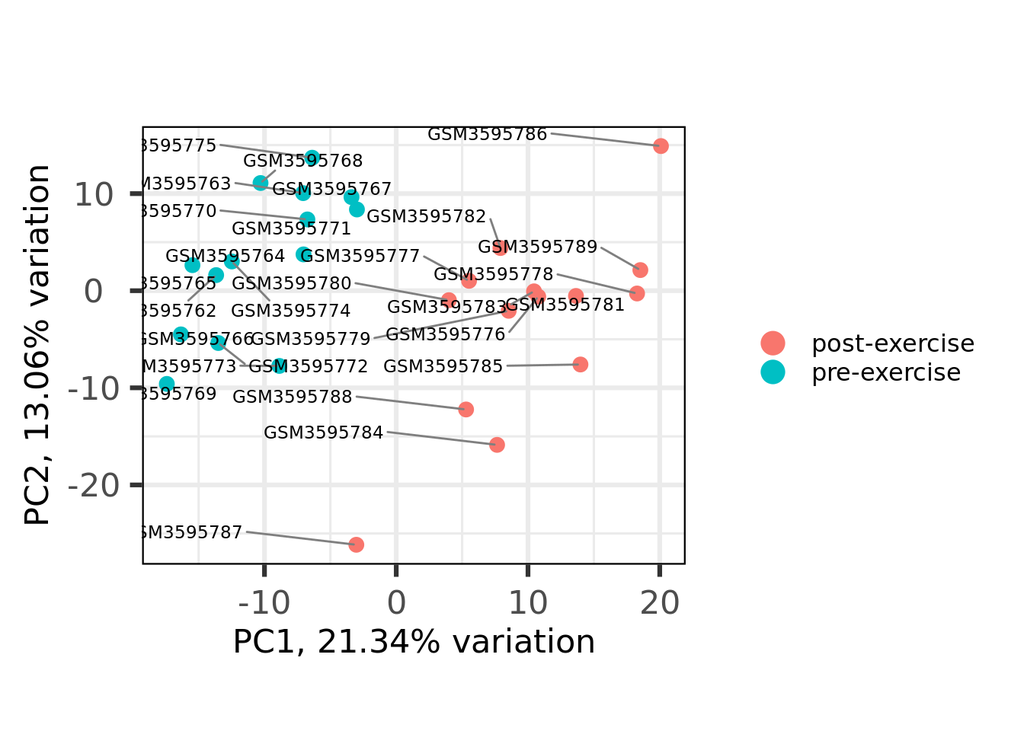

```r
biplot(pcaData, colby="time:ch1", legendPosition = "right")
```

The second component is less clear - there are two other main properties: age and sex. However, all of them are spread more or less evenly across PC2:

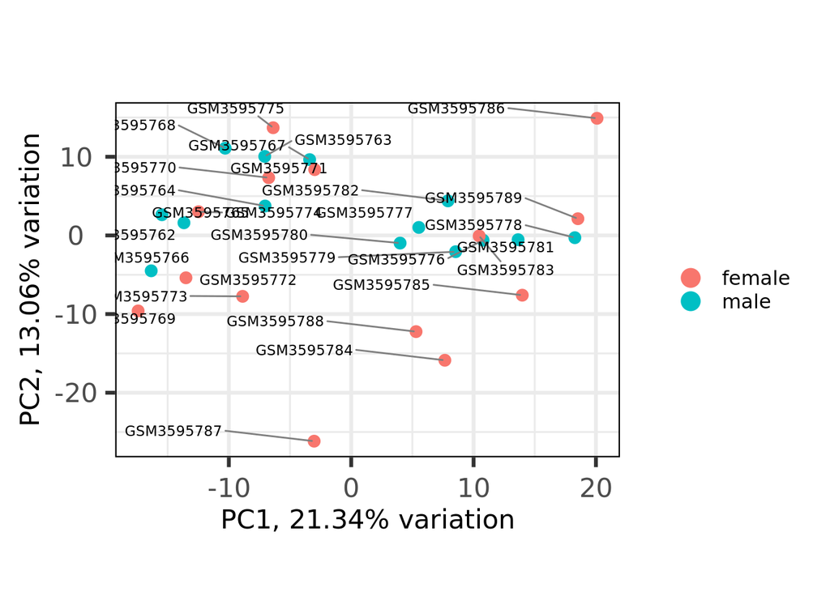

```r
biplot(pcaData, colby="gender:ch1", legendPosition = "right")
```

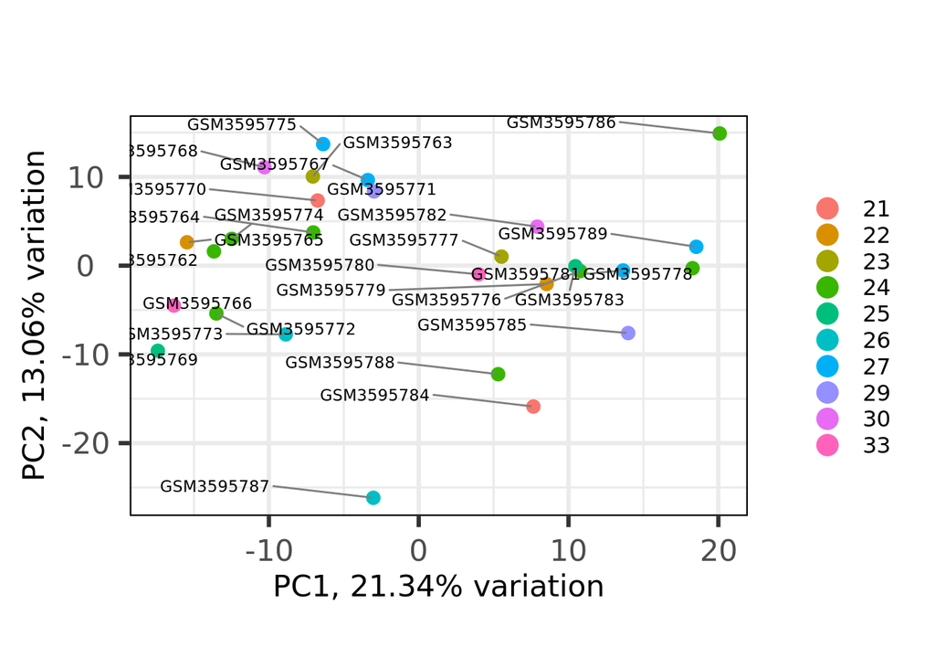

```r
biplot(pcaData, colby="age:ch1", legendPosition = "right")
```

Two samples are quite different from others: GSM3595786 and GSM3595787. They can be potential outliers.

And when we look at the scree plot, it becomes clear that there is no good linear low-dimensional approximation of the samples. Maybe there is a lot of noise, donor and batch effects are too significant.

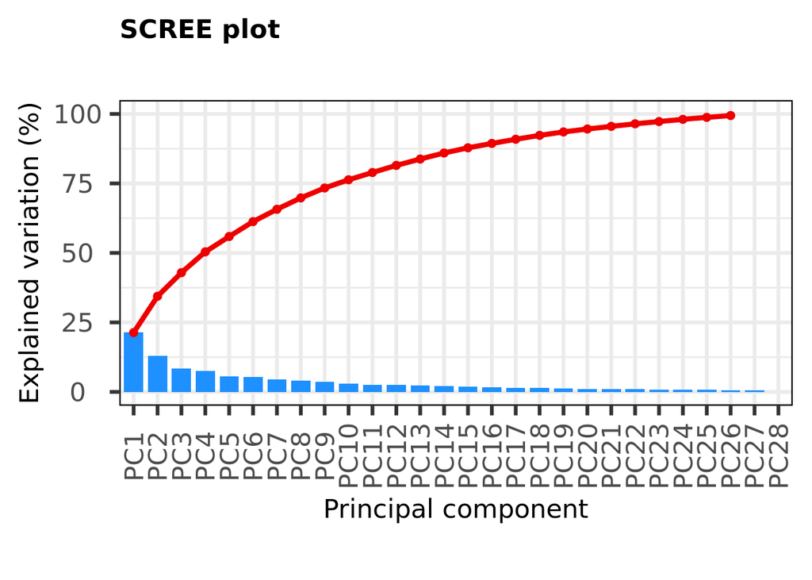

```r
screeplot(pcaData)
```

### 5. DE model for the problem

Since we consider sex a relevant feature, we essentially have four types of treatment: (male, no sprint), (male, sprint), (female, no sprint), (female, sprint). Moreover, since we try to find out the difference between the effect of sprint on men/women, we also cannot treat contribution of sprint as independent from the sex. Then, we need to analyze contribution of sprint separately for men and women.

It is also necessary to account for the donor effect.

Let's first perform DE for men, show top-10 genes by p-value:

```r
es_male <- es[, pData(es)$'gender:ch1' == 'male']
cell_full_model <- model.matrix(~0 + pData(es_male)$'individual:ch1' + pData(es_male)$'time:ch1', data=pData(es_male))

colnames(cell_full_model) <- c('S1', 'S2', 'S3', 'S4', 'S5', 'S6', 'S7',
                               'sprint')

cell_full_model[,'sprint'] <- 1 - cell_full_model[,'sprint']

cell_full_model
```

```
##            S1 S2 S3 S4 S5 S6 S7 sprint
## GSM3595762  1  0  0  0  0  0  0      0
## GSM3595763  0  1  0  0  0  0  0      0
## GSM3595764  0  0  1  0  0  0  0      0
## GSM3595765  0  0  0  1  0  0  0      0
## GSM3595766  0  0  0  0  1  0  0      0
## GSM3595767  0  0  0  0  0  1  0      0
## GSM3595768  0  0  0  0  0  0  1      0
## GSM3595776  1  0  0  0  0  0  0      1
## GSM3595777  0  1  0  0  0  0  0      1
## GSM3595778  0  0  1  0  0  0  0      1
## GSM3595779  0  0  0  1  0  0  0      1
## GSM3595780  0  0  0  0  1  0  0      1
## GSM3595781  0  0  0  0  0  1  0      1
## GSM3595782  0  0  0  0  0  0  1      1
## attr(,"assign")
## [1] 1 1 1 1 1 1 1 2
## attr(,"contrasts")
## attr(,"contrasts")$`pData(es_male)$"individual:ch1"`
## [1] "contr.treatment"
##
## attr(,"contrasts")$`pData(es_male)$"time:ch1"`
## [1] "contr.treatment"
```

```r
fit <- lmFit(es_male, cell_full_model)
fit2 <- contrasts.fit(fit, makeContrasts(sprint, levels=cell_full_model))
fit2 <- eBayes(fit2, trend = T)
de_male <- topTable(fit2, adjust.method="BH", number=Inf, sort.by = "P")
head(de_male, 10)
```

```
##             logFC   AveExpr        t      P.Value    adj.P.Val        B
## PPP1R27  1.216898 11.655404 28.50041 2.058970e-11 1.065165e-07 15.26980
## PIM1     2.698952  8.446239 28.40843 2.130331e-11 1.065165e-07 15.24830
## PMP22    1.516953  9.779163 23.49057 1.571293e-10 5.237642e-07 13.88864
## SLC38A1  1.477247  9.296923 20.43366 6.747996e-10 1.382692e-06 12.78211
## TRIM63   1.403104 11.662696 20.38622 6.913459e-10 1.382692e-06 12.76296
## MGC16025 1.504578  8.039601 18.93253 1.492532e-09 2.263027e-06 12.14252
## CSRNP1   1.700080  7.684195 18.82424 1.584119e-09 2.263027e-06 12.09355
## PPARGC1A 2.317924 11.013408 18.38434 2.024506e-09 2.530633e-06 11.89049
## NR4A1    3.026589 10.707125 17.62534 3.132643e-09 3.480715e-06 11.52369
## EGR1     4.683543 10.847436 16.72322 5.388696e-09 5.388696e-06 11.05872
```

Let's now perform DE for women, show top-10 genes by p-value:

```r
es_female <- es[, pData(es)$'gender:ch1' == 'female']
cell_full_model <- model.matrix(~0 + pData(es_female)$'individual:ch1' + pData(es_female)$'time:ch1', data=pData(es_female))

colnames(cell_full_model) <- c('S10', 'S11', 'S12', 'S13', 'S14', 'S8', 'S9',
                               'sprint')

cell_full_model[,'sprint'] <- 1 - cell_full_model[,'sprint']

cell_full_model
```

```
##            S10 S11 S12 S13 S14 S8 S9 sprint
## GSM3595769   0   0   0   0   0  1  0      0
## GSM3595770   0   0   0   0   0  0  1      0
## GSM3595771   1   0   0   0   0  0  0      0
## GSM3595772   0   1   0   0   0  0  0      0
## GSM3595773   0   0   1   0   0  0  0      0
## GSM3595774   0   0   0   1   0  0  0      0
## GSM3595775   0   0   0   0   1  0  0      0
## GSM3595783   0   0   0   0   0  1  0      1
## GSM3595784   0   0   0   0   0  0  1      1
## GSM3595785   1   0   0   0   0  0  0      1
## GSM3595786   0   1   0   0   0  0  0      1
## GSM3595787   0   0   1   0   0  0  0      1
## GSM3595788   0   0   0   1   0  0  0      1
## GSM3595789   0   0   0   0   1  0  0      1
## attr(,"assign")
## [1] 1 1 1 1 1 1 1 2
## attr(,"contrasts")
## attr(,"contrasts")$`pData(es_female)$"individual:ch1"`
## [1] "contr.treatment"
##
## attr(,"contrasts")$`pData(es_female)$"time:ch1"`
## [1] "contr.treatment"
```

```r
fit <- lmFit(es_female, cell_full_model)
fit2 <- contrasts.fit(fit, makeContrasts(sprint, levels=cell_full_model))
fit2 <- eBayes(fit2, trend = T)
de_female <- topTable(fit2, adjust.method="BH", number=Inf, sort.by = "P")
head(de_female, 10)
```

```
##               logFC   AveExpr        t      P.Value    adj.P.Val         B
## PDK4      0.9156039 12.748941 21.22696 8.528902e-10 4.710056e-06 11.965712
## EGR1      5.5201940 10.928674 21.01748 9.420112e-10 4.710056e-06 11.898883
## KLHL40    1.9079113 10.627636 19.55500 1.938166e-09 6.460553e-06 11.399005
## BHLHE40   1.8685695 10.921942 15.79158 1.618296e-08 4.045739e-05  9.787356
## LOC729603 1.1219741  7.715276 14.87507 2.914418e-08 5.828837e-05  9.306486
## MT1X      0.8353098 11.555814 13.89630 5.673986e-08 8.128217e-05  8.745905
## PCNT      0.8928825 10.586524 13.76560 6.221839e-08 8.128217e-05  8.667073
## NR4A1     3.0202033 10.714424 13.70342 6.502573e-08 8.128217e-05  8.629222
## SLC20A1   1.7618943  8.559624 12.88014 1.187245e-07 1.199511e-04  8.106222
## PIM1      3.0910083  8.710636 12.86373 1.201992e-07 1.199511e-04  8.095371
```

As we can see, there are some genes that are in the top-10 for both males and females: PIM1, NR4A1, EGR1

### 6. DE genes comparison for male vs female

Let's look at volcano plots for female and male datasets.

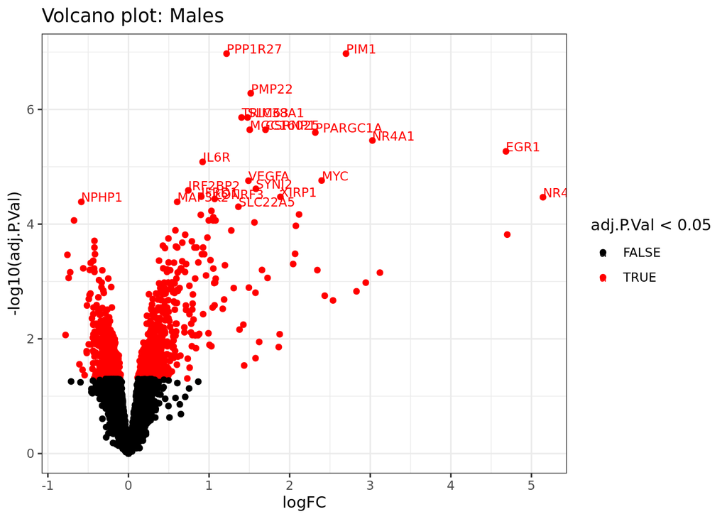

```r
de_male$gene <- row.names(de_male)
de_female$gene <- row.names(de_female)

ggplot(de_male, aes(x=logFC, y=-log10(adj.P.Val), color=adj.P.Val < 0.05)) +
  geom_point() + scale_color_manual(values=c("black", "red")) +
  theme_bw() + ggtitle('Volcano plot: Males') +
  geom_text(aes(label=ifelse(adj.P.Val < 0.00005,gene,'')),hjust=0,vjust=0, size=3)
```

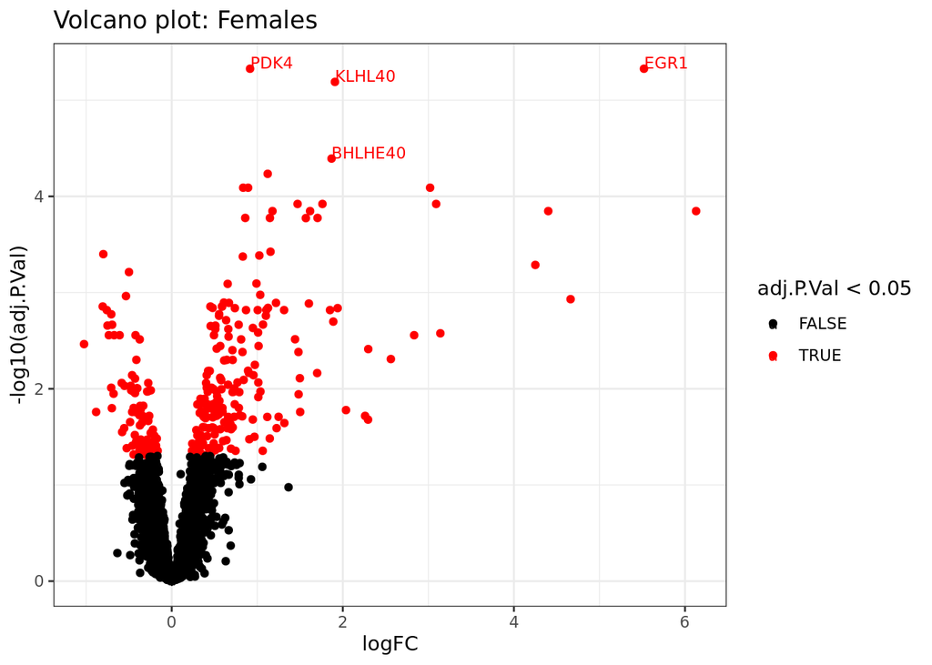

```r
ggplot(de_female, aes(x=logFC, y=-log10(adj.P.Val), color=adj.P.Val < 0.05)) +
  geom_point() + scale_color_manual(values=c("black", "red")) +
  theme_bw() + ggtitle('Volcano plot: Females') +
  geom_text(aes(label=ifelse(adj.P.Val < 0.00005,gene,'')),hjust=0,vjust=0, size=3)
```

First thing that we can notice is a large difference in the number of significant genes. There are 1240 significant genes for males, but only 289 - for females. Gene is significantly differentially expressed if the adjusted p-value is smaller than 0.05.

So, sprint statistically significantly affects many more genes in males relative to females.

If we take top-250 most significant genes in males and females, only 142 will be the same.

Let's look at those different genes. We will compare t-statistic from both datasets and sort genes by the absolute difference in this statistic. That way we will distinguish between the genes that might not both pass the significance threshold, but are still very close (one is 0.049, the other is 0.05), and those that are actually very different for two datasets.

```r
dif_genes <- setdiff(row.names(de_male[1:250, ]),
                     row.names(de_female[1:250, ]))

dif_gene_comparison <- cbind(de_male[dif_genes, c('t', 'adj.P.Val')],
                             de_female[dif_genes, c('t', 'adj.P.Val')])

colnames(dif_gene_comparison) <- c('t1', 'pval1', 't2', 'pval2')
dif_gene_comparison$dif_t <- abs(dif_gene_comparison$t1 - dif_gene_comparison$t2)

dif_gene_comparison <- dif_gene_comparison[order(dif_gene_comparison$dif_t, decreasing = T), ]

head(dif_gene_comparison, 50)
```

```
##                  t1        pval1         t2      pval2    dif_t
## ASB5       9.889925 0.0002457410  1.8926402 0.43484457 7.997285
## ANGPTL2   10.821452 0.0001289232  4.1364553 0.05929439 6.684997
## RSRP1     -9.050040 0.0004353217 -2.7465240 0.22144826 6.303516
## IDI1       9.071606 0.0004331515  3.0429004 0.16772416 6.028706
## C8orf22   -7.909001 0.0009456095 -1.8917509 0.43526878 6.017250
## DOK7       8.622323 0.0005901161  2.6495635 0.23897026 5.972759
## MAP2K3     8.913315 0.0004702012  2.9705858 0.17886631 5.942729
## FAM102A    7.398722 0.0013955308  1.6514210 0.50916168 5.747301
## SNAI3      6.327075 0.0034498217  0.6044717 0.85728897 5.722603
## ARVCF      5.925269 0.0052112416  0.2665387 0.94256559 5.658731
## VGLL2      9.739139 0.0002554694  4.1759335 0.05750534 5.563206
## ABCA10     7.510305 0.0012791484  2.1083553 0.36836878 5.401950
## MKKS      -8.324524 0.0006802962 -2.9278454 0.18867601 5.396678
## NAT8       6.034716 0.0046186022  0.7465956 0.81209155 5.288120
## MYO10     -9.330502 0.0003431831 -4.1025318 0.06082696 5.227970
## KLF3       6.883326 0.0021176903  1.7446836 0.48153369 5.138642
## RRAGC      7.188773 0.0016224769  2.1382603 0.36068718 5.050513
## CSF3       7.153029 0.0016620487  2.1029304 0.37063440 5.050099
## GPCPD1     7.606041 0.0011876521  2.5627081 0.25791134 5.043333
## SMPDL3A    6.824143 0.0022397504  1.8100797 0.46140166 5.014063
## CES3       9.374413 0.0003342505  4.4546284 0.04415435 4.919785
## KLHL21     7.523403 0.0012759701  2.6211308 0.24467774 4.902273
## RUNX1      5.814233 0.0056602467  0.9862611 0.73355811 4.827971
## MIER1     -7.366681 0.0014390662 -2.5425862 0.26183422 4.824095
## MYOM2      7.137979 0.0016692670  2.3458320 0.30785118 4.792147
## ADRB2      6.036442 0.0046186022  1.2823466 0.63495306 4.754095
## GPR157     8.818739 0.0004959982  4.0783976 0.06173182 4.740341
## DAAM2      5.875073 0.0054439698  1.2076295 0.66112414 4.667443
## TBC1D8     8.262824 0.0006972910  3.6847817 0.08876484 4.578042
## SLED1      8.948004 0.0004656482  4.3788761 0.04726021 4.569128
## TANGO2     8.603344 0.0005901161  4.1053904 0.06082696 4.497954
## STRIP2     6.100311 0.0043556560  1.6481907 0.51052669 4.452121
## NOCT       6.216242 0.0038293337  1.8828513 0.43738246 4.333390
## HEY1       8.445611 0.0006302626  4.1215232 0.06019022 4.324088
## DGKD       7.472622 0.0013017017  3.1562145 0.15097137 4.316407
## FAM110B    7.348385 0.0014593354  3.1681092 0.14960169 4.180276
## PODXL      6.954265 0.0020230245  2.7904184 0.21433221 4.163847
## NUP37     -5.861025 0.0054528500 -1.7258513 0.48652584 4.135174
## ZCCHC8     6.393962 0.0032376952  2.2643602 0.32574457 4.129602
## FAM118A    7.622008 0.0011762077  3.4978220 0.10741569 4.124186
## PIK3R3     5.720140 0.0061567509  1.6401365 0.51237021 4.080004
## TNFRSF12A  7.986136 0.0008889623  3.9237614 0.07194917 4.062375
## SLC9A3R2   8.316973 0.0006802962  4.3079231 0.05015839 4.009050
## TUBB2A     5.864345 0.0054528500  2.0040983 0.40405421 3.860246
## SIKE1     -5.757708 0.0059792740 -1.9555405 0.41560973 3.802167
## MURC      -7.980774 0.0008889623 -4.2106013 0.05598109 3.770173
## VPS36     -5.971977 0.0049018949 -2.2060655 0.33873776 3.765912
## ZFP3      -5.743476 0.0060271617 -1.9897057 0.40685745 3.753770
## CISH       7.753393 0.0010466494  4.0068085 0.06483893 3.746584
## ABCB6     -5.796832 0.0057009204 -2.0871803 0.37467920 3.709651
```

Alternatively, we can also take all statistically significant genes in males and choose from them those that have different t-statistic in male and female datasets:

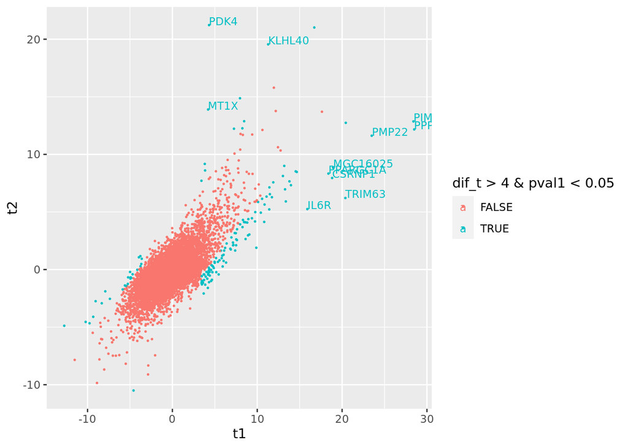

```r
dif_gene_comparison <- merge(de_male[, c('t', 'adj.P.Val')],
                             de_female[, c('t', 'adj.P.Val')], by=0)

colnames(dif_gene_comparison) <- c('gene', 't1', 'pval1', 't2', 'pval2')
dif_gene_comparison$dif_t <- abs(dif_gene_comparison$t1 - dif_gene_comparison$t2)

ggplot(dif_gene_comparison, aes(x = t1, y = t2,
                                col = dif_t > 4 & pval1 < 0.05,
                                label = gene)) +
  geom_point(size=0.3) +
  geom_text(aes(label=ifelse(dif_t > 8 & pval1 < 0.05,gene,'')),hjust=0,vjust=0, size=3)
```

Since both options are more or less ad hoc, I think it is fair to choose any one of them.

### 7. MSigDB pathway analysis

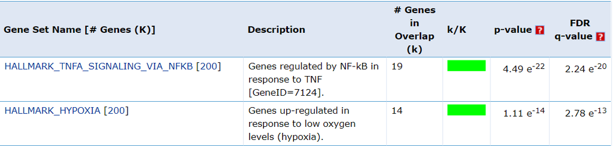

On the plot below, we can see that hypoxia pathway is very significantly differentially expressed in both females and males, adjusted p-value for every gene is lower than 0.05.

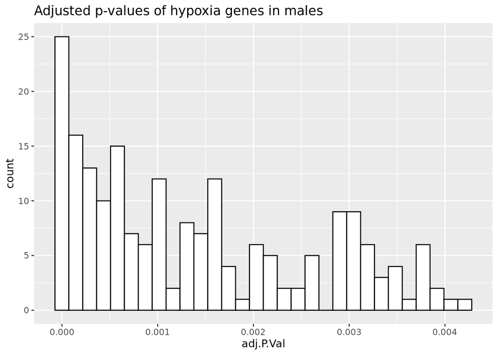

```r
pathway <- unlist(read.csv('hypoxia.txt', skip = 1)[,1])

ggplot(de_male[pathway, ], aes(x=adj.P.Val)) +
  geom_histogram(fill='white', col='black') +
  ggtitle('Adjusted p-values of hypoxia genes in males')
```

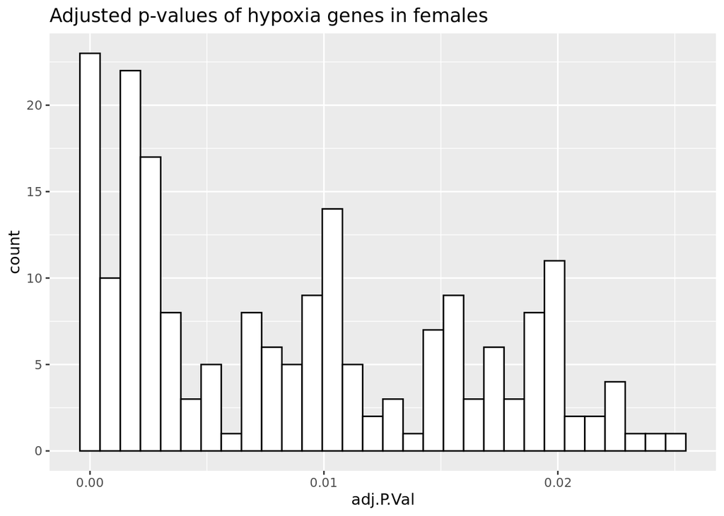

```r
ggplot(de_female[pathway, ], aes(x=adj.P.Val)) +
  geom_histogram(fill='white', col='black') +
  ggtitle('Adjusted p-values of hypoxia genes in females')
```

### 8. Conclusion

It was found that although the regulation pattern of sprint is similar for men and women, and there are shared pathways that are significantly differentially expressed, there are also some genes that behave statistically differently for two sexes.